# Estudio Viviendas Ciudad Melbourne

Daniela Corbetta

2024-08-14

El caso de negocio presentado hace referencia a la información sobre las vivienda en Melbourne, ciudad australiana. El conjunto de datos utilizado contiene variables que pueden ayudar a determinar el coste de una casa o apartamento: el número de habitaciones, la superficie del edificio, su localización, el tamaño del terreno, etc.

El objetivo del estudio, por lo tanto, es llevar a cabo una regresión para predecir el precio de la vivienda, utilizando un modelo fiable y computacionalmente eficiente en términos de tiempos y costes.

### Cargar librerías

```r
rm(list = ls())

suppressWarnings({

    # --Rmarkdown theme
    # library(rmdformats)
    # library(prettydoc)
    # library(hrbrthemes)
    # library(tint)
    # library(tufte)

    #-- Data cleaning
    library(data.table)
    library(tidytable)
    library(dplyr)
    library(tidyverse)

    #-- Automatic EDA + estudio con datos georeferenciados
    library(DataExplorer)
    library(inspectdf)
    library(skimr)
    library(summarytools)
    library(sf)
    library(absmapsdata)

    #-- Execution time
    library(tictoc)

    #-- Tables output
    library(flextable)
    library(kableExtra)

    #-- Missing imputation
    library(missRanger)

    #-- Graphics
    library(ggplot2)
    library(patchwork)

    #-- Correlation plot
    library(corrplot)

    #-- Modeling
    library(caret)
    library(h2o)
    library(glmnet)

    #-- Miscelaneous
    library(tibble)
    library(stringr)
    library(forcats)

    #-- Explainability
    library(DALEX)
    library(DALEXtra)


})
```

### Cargar dataset

```r
# leer el dataset
datMelbourne <- fread("./datos_casas_melbourne.csv") %>%
  as.data.table()

# mostrar las primeras 5 filas
datMelbourne %>%
  head(5) %>%
  kbl(caption = "Conjunto de datos original") %>%
  kable_minimal()
```

Conjunto de datos original

| Rooms | Type | Bedroom2 | Bathroom | Landsize | Lattitude | Longtitude | Regionname | Propertycount | Price |
| --- | --- | --- | --- | --- | --- | --- | --- | --- | --- |
| 2 | h | 2 | 1 | 202 | -37.7996 | 144.9984 | ‘Northern Metropolitan’ | 4019 | 1480000 |
| 2 | h | 2 | 1 | 156 | -37.8079 | 144.9934 | ‘Northern Metropolitan’ | 4019 | 1035000 |
| 3 | h | 3 | 2 | 134 | -37.8093 | 144.9944 | ‘Northern Metropolitan’ | 4019 | 1465000 |
| 3 | h | 3 | 2 | 94 | -37.7969 | 144.9969 | ‘Northern Metropolitan’ | 4019 | 850000 |
| 4 | h | 3 | 1 | 120 | -37.8072 | 144.9941 | ‘Northern Metropolitan’ | 4019 | 1600000 |

Explicación de las variables:  
- **Rooms**: Número de habitaciones.  
- **Type**: es el tipo de vivienda (**h** se refiere a casa, cabaña, villa, semi, terraza; **u** se refiere a unidad o dúplex; **t** se refiere a casa adosada; sitio de desarrollo; u otros lugares residenciales).  
- **Bedrooms2**: Número de dormitorios.  
- **Bathroom**: Número de baños.  
- **Landsize**: Tamaño del terreno.  
- **Lattitude**: Latitud.  
- **Longtitude**: Longitud.  
- **Regionname**: Localización en la región de Victoria (‘Eastern Metropolitan’, ‘Eastern Victoria’, ‘Northern Metropolitan’, ‘Northern Victoria’, ‘South-Eastern Metropolitan’, ‘Southern Metropolitan’, ‘Western Metropolitan’ y ‘Western Victoria’).  
- **Propertycount**: Número de propiedades que existen en el suburbio.  
- **Price**: Precio en dólares de la vivienda.

La dimensión del conjunto de variables no es elevada, aunque a primera vista se observa que algunas de ellas necesitan unos ajustes.

```r
# inspección caracteristicas de las variables
skim(datMelbourne)
```

Data summary

| Name | datMelbourne |
| --- | --- |
| Number of rows | 13580 |
| Number of columns | 10 |
| Key | NULL |
| _______________________ |  |
| Column type frequency: |  |
| character | 2 |
| numeric | 8 |
| ________________________ |  |
| Group variables | None |

**Variable type: character**

| skim_variable | n_missing | complete_rate | min | max | empty | n_unique | whitespace |
| --- | --- | --- | --- | --- | --- | --- | --- |
| Type | 0 | 1 | 1 | 1 | 0 | 3 | 0 |
| Regionname | 0 | 1 | 18 | 28 | 0 | 8 | 0 |

**Variable type: numeric**

| skim_variable | n_missing | complete_rate | mean | sd | p0 | p25 | p50 | p75 | p100 | hist |
| --- | --- | --- | --- | --- | --- | --- | --- | --- | --- | --- |
| Rooms | 0 | 1 | 2.94 | 0.96 | 1.00 | 2.00 | 3.0 | 3.00 | 10.00 | ▅▇▁▁▁ |
| Bedroom2 | 0 | 1 | 2.91 | 0.97 | 0.00 | 2.00 | 3.0 | 3.00 | 20.00 | ▇▁▁▁▁ |
| Bathroom | 0 | 1 | 1.53 | 0.69 | 0.00 | 1.00 | 1.0 | 2.00 | 8.00 | ▇▆▁▁▁ |
| Landsize | 0 | 1 | 558.42 | 3990.67 | 0.00 | 177.00 | 440.0 | 651.00 | 433014.00 | ▇▁▁▁▁ |
| Lattitude | 0 | 1 | -37.81 | 0.08 | -38.18 | -37.86 | -37.8 | -37.76 | -37.41 | ▁▂▇▁▁ |
| Longtitude | 0 | 1 | 145.00 | 0.10 | 144.43 | 144.93 | 145.0 | 145.06 | 145.53 | ▁▁▇▂▁ |
| Propertycount | 0 | 1 | 7454.42 | 4378.58 | 249.00 | 4380.00 | 6555.0 | 10331.00 | 21650.00 | ▆▇▅▂▁ |
| Price | 0 | 1 | 1075684.08 | 639310.72 | 85000.00 | 650000.00 | 903000.0 | 1330000.00 | 9000000.00 | ▇▁▁▁▁ |

### Exploratory Data Analysis

Se procede a una primera fase de Análisis Exploratorio de los datos, con pequeñas modificaciones de carácter estético.

```r
# se crea un nuevo data.table para mantener el original
datMelbourneMod <- datMelbourne %>%
  select(everything()) %>%
  as.data.table()
```

```r
# se renombran algunas variables para que sean más transparentes
names(datMelbourneMod)[6] = "Lat"
names(datMelbourneMod)[7] = "Lng"
names(datMelbourneMod)[9] = "Properties"
```

```r
# se eliminan filas duplicadas
datMelbourneMod %<>%
  distinct() %>%
  as.data.table()
```

```r
# se cambian las variables categoricas a factores
datMelbourneMod %<>%
  mutate(Type       = as.factor(Type)) %>%
  mutate(Regionname = as.factor(Regionname)) %>%
  as.data.table()
```

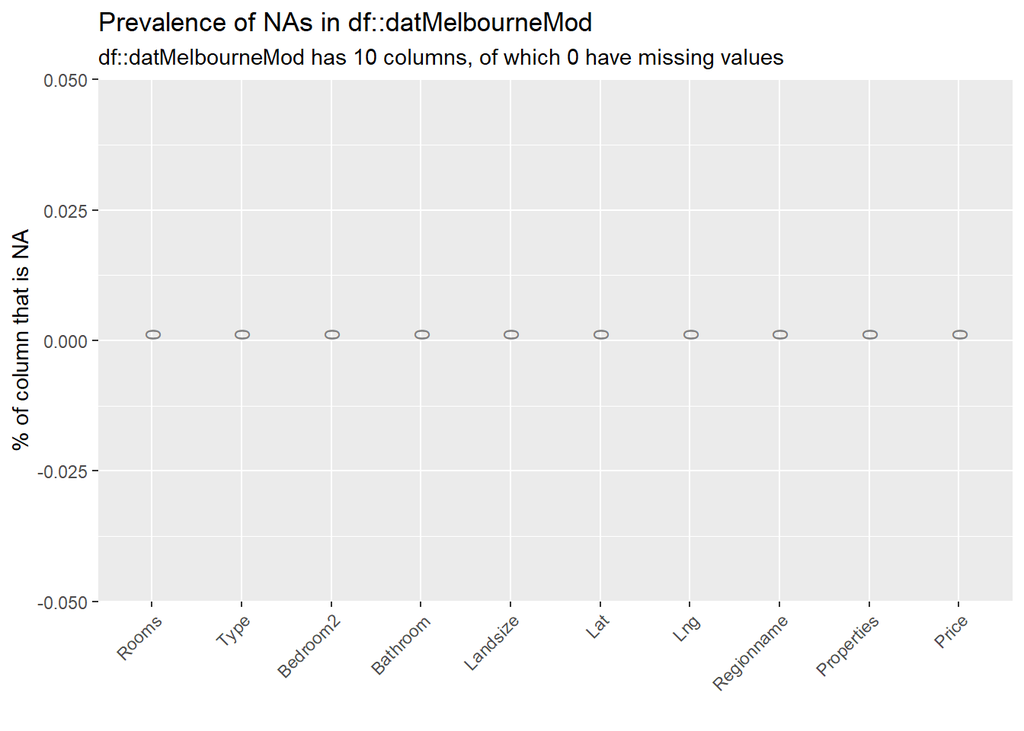

```r
# se inspecciona la presencia de NAs en todas las variables
x <- inspect_na(datMelbourneMod)
show_plot(x)
```

A primera vista parece que no hay NAs, sin embargo, desde el analisis skim ha aparecido una distribución ánomala de la variable Landsize que indica el tamaño del terreno: hay valores iguales a 0, que seguramente proceden de una recopilación de datos poco exacta.

```r
# se transforman los 0 en NAs
datMelbourneMod <- datMelbourneMod %>%
  mutate(Landsize = ifelse(Landsize == 0, NA, Landsize))
```

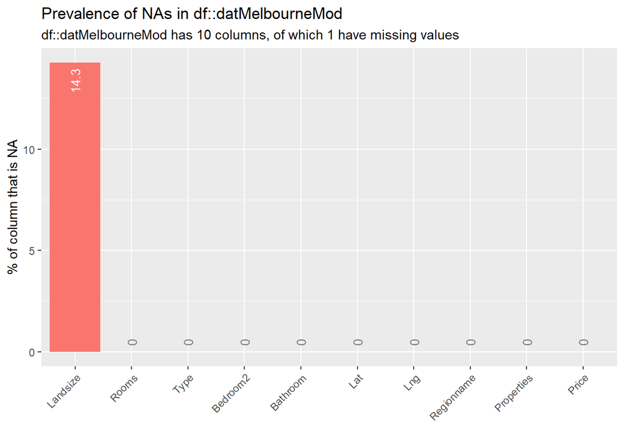

```r
# se representa el monto de NAs presentes en las variables
x <- inspect_na(datMelbourneMod)
show_plot(x)
```

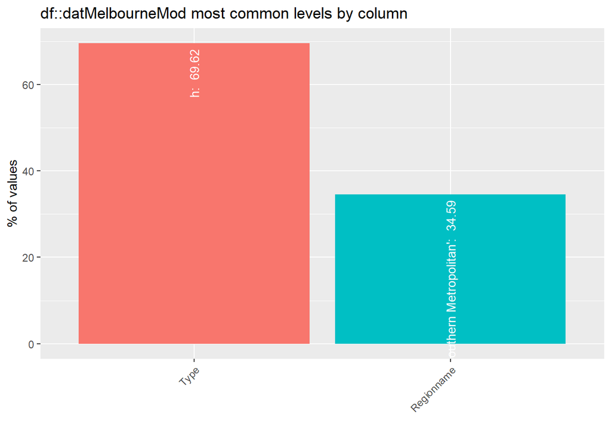

```r
x <- inspect_imb(datMelbourneMod)
show_plot(x)
```

```r
# se muestra la distribución de cada nivel de la variable Type
datMelbourneMod |>
  count(Type) |>
  mutate(porc = 100 * n / sum(n))
```

```
##      Type     n      porc
##    <fctr> <int>     <num>
## 1:      h  9439 69.624548
## 2:      t  1111  8.195028
## 3:      u  3007 22.180423
```

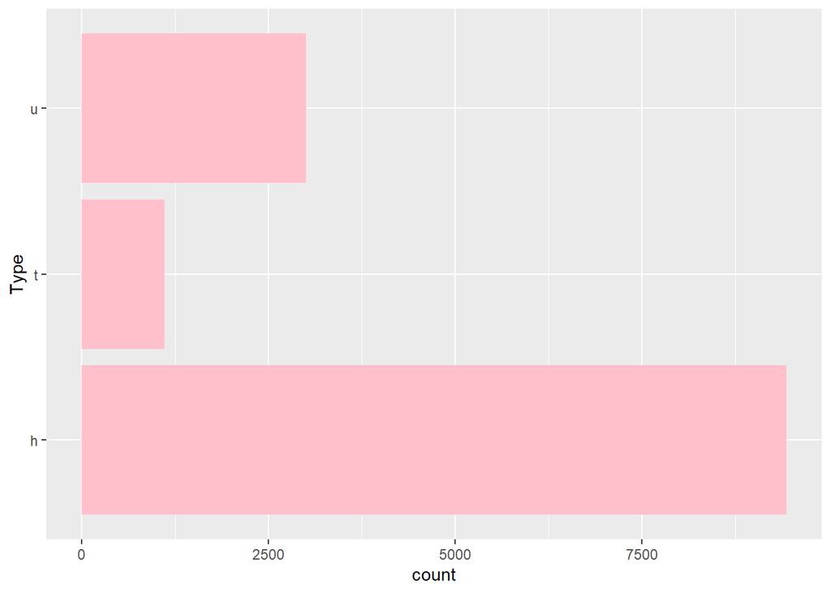

```r
datMelbourneMod |>
  ggplot() +
  geom_bar(aes(y=Type), fill = "pink")
```

```r
# se muestra la distribución de cada nivel de la variable Regionname
datMelbourneMod |>
  count(Regionname) |>
  mutate(porc = 100 * n / sum(n))
```

```
##                      Regionname     n       porc
##                          <fctr> <int>      <num>
## 1:       'Eastern Metropolitan'  1471 10.8504831
## 2:           'Eastern Victoria'    53  0.3909419
## 3:      'Northern Metropolitan'  3878 28.6051486
## 4:          'Northern Victoria'    41  0.3024268
## 5: 'South-Eastern Metropolitan'   448  3.3045659
## 6:      'Southern Metropolitan'  4689 34.5872981
## 7:       'Western Metropolitan'  2945 21.7230951
## 8:           'Western Victoria'    32  0.2360404
```

```r
# se calcula el total de observaciones que no pertenecen a Melbourne ciudad
datos_filtrados <- datMelbourneMod[grepl("Victoria", datMelbourneMod$Regionname), ]
total_filas <- nrow(datMelbourneMod)
porcentaje_victoria <- (nrow(datos_filtrados) / total_filas) * 100
porcentaje_victoria
```

```
## [1] 0.9294092
```

```r
# se cambian los valores Regionname para que no den problemas en la parte de modelado
datMelbourneMod$Regionname <- factor(datMelbourneMod$Regionname,
                                     labels = c("EasternMetropolitan", "EasternVictoria", "NorthernMetropolitan",
                                                "NorthernVictoria", "SouthEasternMetropolitan", "SouthernMetropolitan",
                                                "WesternMetropolitan", "WesternVictoria"))
```

```r
datMelbourneMod_regionPrecio <- datMelbourneMod %>%
  group_by(Regionname) %>%
  summarise(Precio_promedio = mean(as.numeric(Price)))
```

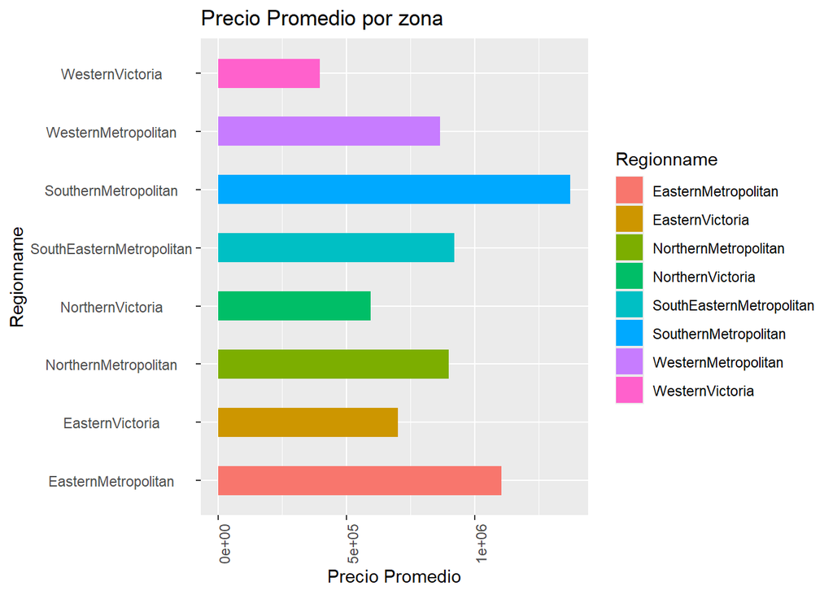

```r
# se representa graficamente la relación entre la región y el precio medio de la vivienda
colors <- c("red", "blue", "green", "orange", "purple", "teal")

ggplot(datMelbourneMod_regionPrecio, aes(x = Precio_promedio, y = Regionname, fill = Regionname)) +
  geom_bar(stat = "identity", width = 0.5) +
  labs(title = "Precio Promedio por zona",
       x = "Precio Promedio",
       y = "Regionname")    +
  theme(
    axis.text.x = element_text(angle = 90),
    axis.text.y = element_text(angle = 0, hjust = 0.5)
  )
```

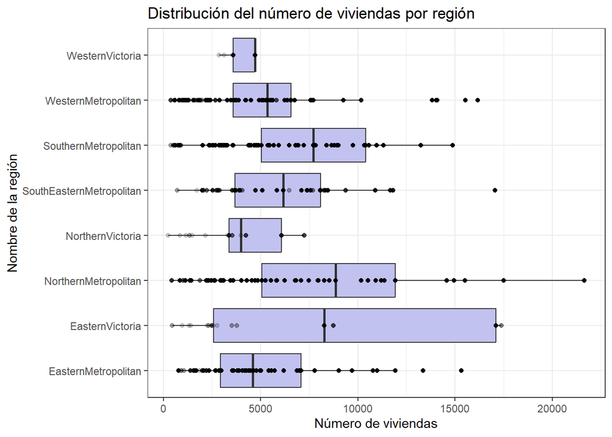

```r
# se mira la distribución del número de viviendas por región
ggplot(data = datMelbourneMod, aes(y = Regionname, x = Properties)) +
  geom_boxplot(fill = "#c2c2f0", notch = FALSE) +
  geom_point(alpha = 0.2) +
  labs(title = "Distribución del número de viviendas por región",
       x = "Número de viviendas",
       y = "Nombre de la región") +
  theme_bw()
```

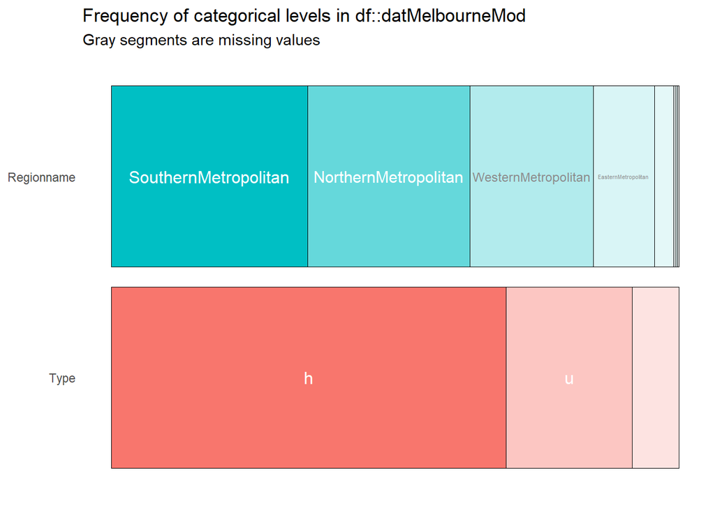

```r
# se mira la distribución de cada nivel en las variables factor
x <- inspect_cat(datMelbourneMod)
show_plot(x)
```

```r
# se seleccionan las variables númericas
datMelbourneMod_num <- datMelbourneMod %>%
  select_if(is.numeric) %>%
  na.omit()
```

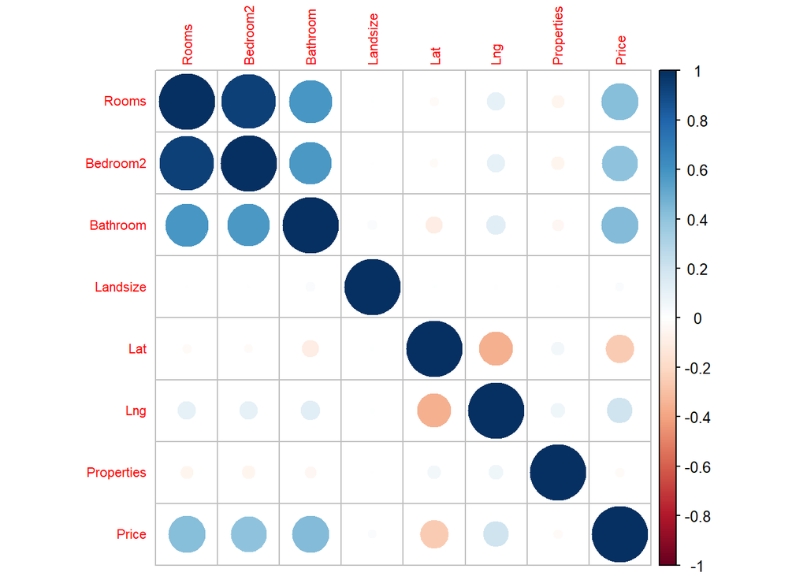

```r
# se grafica la correlación entre las variables númericas
correlation_matrix <- cor(datMelbourneMod_num)
corrplot(correlation_matrix, method = "circle", tl.cex = 0.7, na.col = "white")
```

```r
# se comprueba que las variables no tienen varianza cero
zero_variance_vars <- names(datMelbourneMod_num)[which(var(datMelbourneMod_num) == 0)]

# declaración del resultado
if (length(zero_variance_vars) > 0) {
  message("**Variables con varianza cero:**")
  print(data.frame(Variable = zero_variance_vars, stringsAsFactors = FALSE))
} else {
  message("**No hay variables con varianza cero**")
}
```

```
## **No hay variables con varianza cero**
```

```r
# escalado de la variable Price
datMelbourneMod$Price <- log(datMelbourneMod$Price)
```

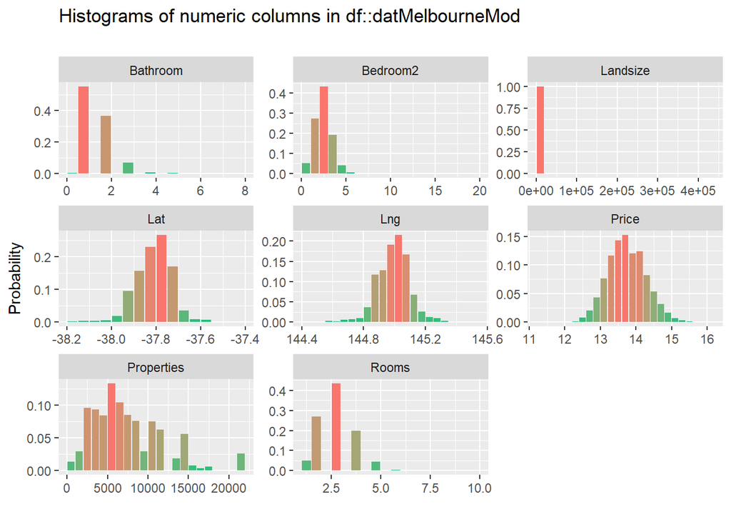

```r
# se muestra la distribución de las variables númericas
x <- inspect_num(datMelbourneMod)
show_plot(x)
```

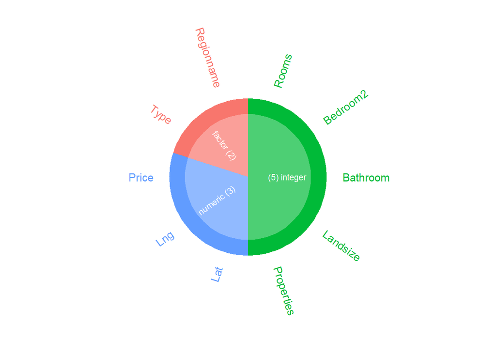

```r
# todas las variables
x <- inspect_types(datMelbourneMod)
show_plot(x)
```

Algunas conclusiones relevantes:

Para satisfacer las necesidades prácticas empresariales, se tomarán algunas decisiones con respecto a la siguiente etapa del proyecto:  
- A pesar de ser un número consistente de datos faltantes, se imputará la variable Landsize, porqué se considera importante poder utilizar todo el conjunto de la muestra para predecir el precio final de la vivienda  
- Se analizará la dependencia entre la variable de Precio y Número de viviendas en el barrio para entender si existe alguna relación.  
- Para evitar problemas de correlaciones, procederemos a eliminar la variable Rooms.

### Estudio con datos espaciales

```r
# se instalan los paquetes necesarios
remotes::install_github("runapp-aus/strayr")
strayr::read_correspondence_tbl
```

[output not shown]

```r
strayr::read_absmap("sa32016")
```

```
## Simple feature collection with 358 features and 11 fields (with 18 geometries empty)
## Geometry type: MULTIPOLYGON
## Dimension:     XY
## Bounding box:  xmin: 96.81695 ymin: -43.74048 xmax: 167.9969 ymax: -9.219937
## Geodetic CRS:  WGS 84
## First 10 features:
##    sa3_code_2016       sa3_name_2016 sa4_code_2016  sa4_name_2016 gcc_code_2016
## 1          10102          Queanbeyan           101 Capital Region         1RNSW
## 2          10103     Snowy Mountains           101 Capital Region         1RNSW
## 3          10104         South Coast           101 Capital Region         1RNSW
## 4          10105 Goulburn - Mulwaree           101 Capital Region         1RNSW
## 5          10106        Young - Yass           101 Capital Region         1RNSW
## 6          10201             Gosford           102  Central Coast         1GSYD
## 7          10202               Wyong           102  Central Coast         1GSYD
## 8          10301            Bathurst           103   Central West         1RNSW
```

[output cut: 24 more lines]

```r
options(timeout = 1000)
remotes::install_github("wfmackey/absmapsdata")
```

```r
# dataset de referencia de la región de Victoria
mapdata1 <- sa32016
```

```r
# se filtran solo los que se refieren a Melbourne
datosFiltrados <- subset(mapdata1, gcc_name_2016 == "Greater Melbourne" & st_is_empty(geometry) == FALSE)
```

```r
# se agrupan según la zona
grouped_data <- datosFiltrados %>%
  group_by(sa4_name_2016)
```

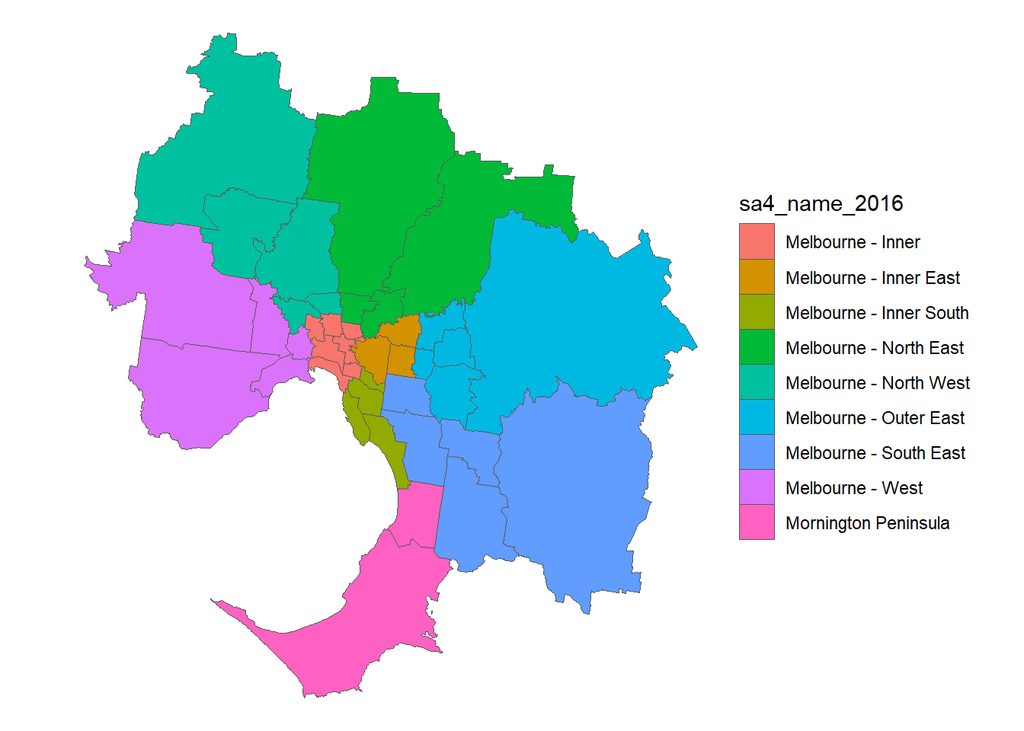

```r
map <- grouped_data %>%
  ggplot() +
  geom_sf(aes(geometry = geometry,
              fill = sa4_name_2016),
          lwd = 0,
          show.legend = TRUE) +
  theme_void() +
  coord_sf()

map
```

A partir de este punto, se han hecho comprobaciones manuales de algunas localizaciones aprovechando de los datos de Longitud y Latitud, presentes tanto en el dataset inicial, como en aquel que está disponible en el paquete `absmapsdata` para Australia (https://github.com/wfmackey/absmapsdata?tab=readme-ov-file). Las comprobaciones manuales se han hecho a través de esta página: [aquí](https://www.gps-coordinates.net/)

```r
grouped_data <- grouped_data %>%
  mutate(sa4_name_2016 = ifelse(sa4_name_2016 %in% c("Melbourne - North East", "Melbourne - North West"), "Melbourne - North", sa4_name_2016))
```

```r
unique(grouped_data$sa4_name_2016)
```

```
## [1] "Melbourne - Inner"       "Melbourne - Inner East"
## [3] "Melbourne - Inner South" "Melbourne - North"
## [5] "Melbourne - Outer East"  "Melbourne - South East"
## [7] "Melbourne - West"        "Mornington Peninsula"
```

```r
# se procede a normalizar los nombres según las etiquetas presentes en el dataset original sobre las viviendas de Melbourne - para hacerlo se consulta la página [aquí](https://www.gps-coordinates.net/)
north_argupado <- c("Inner", "EasternMetropolitan",  "SouthernMetropolitan", "NorthernMetropolitan", "EasternVictoria", "SouthEasternMetropolitan",  "WesternMetropolitan", "Mornington Peninsula")
grouped_data$sa4_name_2016 <- factor(grouped_data$sa4_name_2016)
levels(grouped_data$sa4_name_2016) <- north_argupado
```

```r
# se renombra también la columna para su facilidad de uso
setnames(grouped_data, "sa4_name_2016", "Regionname")
```

```r
# se combinan los dos datasets para enlazar la información
datasetCombinado <- datMelbourneMod_regionPrecio %>%
  full_join(grouped_data, by = "Regionname") %>%
  mutate(Precio_promedio = coalesce(Precio_promedio, NA))
```

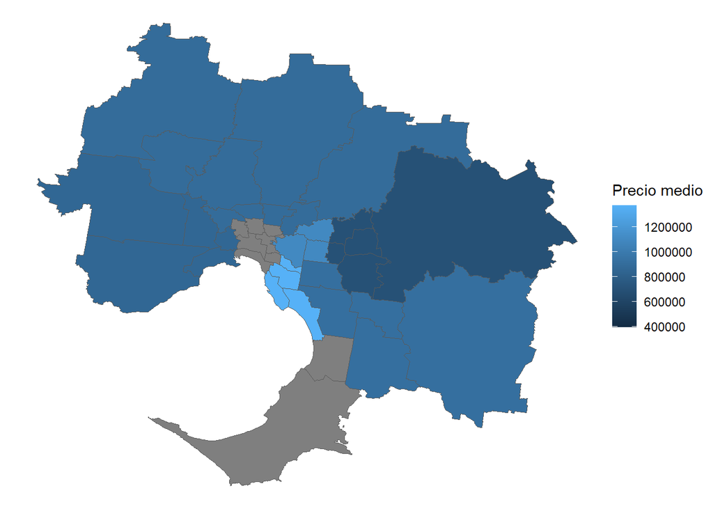

```r
# se representa graficamente en qué zonas el precio es más alto en media
map <- datasetCombinado %>%
  filter(!is.na(geometry)) %>%
  ggplot() +
  geom_sf(aes(geometry = geometry,
              fill = Precio_promedio),
          lwd = 0,
          show.legend = TRUE) +
  theme_void() +
  labs(fill = "Precio medio")

map
```

Como se puede observar las vivienda encarecen cerca de la costa y del centro de la ciudad, mientras que la zona Este presenta una media de precios más barata - Se podría investigar el por qué con más datos. Para las áreas de Centro y Mornington Penisula no hay datos de viviendas disponibles.

### Modelo inicial H2o

```r
library(h2o)
h2o.init()
```

```
##
## H2O is not running yet, starting it now...
##
## Note:  In case of errors look at the following log files:
##     C:\Users\DANIEL~1\AppData\Local\Temp\RtmpI5tMdQ\file4bbcb475cab/h2o_DanielaCorbetta_started_from_r.out
##     C:\Users\DANIEL~1\AppData\Local\Temp\RtmpI5tMdQ\file4bbc46b33372/h2o_DanielaCorbetta_started_from_r.err
##
##
## Starting H2O JVM and connecting:  Connection successful!
##
## R is connected to the H2O cluster:
##     H2O cluster uptime:         4 seconds 479 milliseconds
##     H2O cluster timezone:       Europe/Paris
##     H2O data parsing timezone:  UTC
##     H2O cluster version:        3.44.0.3
##     H2O cluster version age:    7 months and 25 days
##     H2O cluster name:           H2O_started_from_R_DanielaCorbetta_cas495
##     H2O cluster total nodes:    1
##     H2O cluster total memory:   3.47 GB
##     H2O cluster total cores:    12
##     H2O cluster allowed cores:  12
##     H2O cluster healthy:        TRUE
##     H2O Connection ip:          localhost
##     H2O Connection port:        54321
##     H2O Connection proxy:       NA
##     H2O Internal Security:      FALSE
##     R Version:                  R version 4.4.1 (2024-06-14 ucrt)
```

```r
h2o.no_progress()

data  <- as.h2o(datMelbourneMod)

train <- h2o.splitFrame(data, ratios = c(0.7, 0.15), seed = 1)[[1]]
valid <- h2o.splitFrame(data, ratios = c(0.7, 0.15), seed = 1)[[2]]
test  <- h2o.splitFrame(data, ratios = c(0.7, 0.15), seed = 1)[[3]]

y     <- "Price"
x     <- setdiff(names(data), y)

print(x)
```

```
## [1] "Rooms"      "Type"       "Bedroom2"   "Bathroom"   "Landsize"
## [6] "Lat"        "Lng"        "Regionname" "Properties"
```

```r
aml <- h2o.automl(
                    x                  = x,
                    y                  = y,
                    training_frame     = train,
                    validation_frame   = valid,
                    nfold              = 3,
                    max_runtime_secs   = 300,
                    stopping_metric    = "RMSE",
                    exclude_algos      = c("GLM", "StackedEnsemble"),
                    stopping_tolerance = 0.1,
                    stopping_rounds    = 5,
                    seed               = 12345,
                    sort_metric        = c("RMSE")
                 )
```

```
##
## 16:48:53.742: User specified a validation frame with cross-validation still enabled. Please note that the models will still be validated using cross-validation only, the validation frame will be used to provide purely informative validation metrics on the trained models.
## 16:48:53.773: AutoML: XGBoost is not available; skipping it.
```

```r
lb <- aml@leaderboard

#-- Tabla de modelos top-10 y worst-10.
lb_df <- as.data.frame(lb)
lb_df %>%
  head(10) %>%
  kbl(caption = "Top-10 Mejores Modelo Ejecutados - Ordenados por RMSE") %>%
  kable_minimal()
```

Top-10 Mejores Modelo Ejecutados - Ordenados por RMSE

| model_id | rmse | mse | mae | rmsle | mean_residual_deviance |
| --- | --- | --- | --- | --- | --- |
| GBM_4_AutoML_1_20240814_164853 | 0.2018387 | 0.0407388 | 0.1499579 | 0.0136436 | 0.0407388 |
| GBM_2_AutoML_1_20240814_164853 | 0.2019032 | 0.0407649 | 0.1500426 | 0.0136446 | 0.0407649 |
| GBM_3_AutoML_1_20240814_164853 | 0.2023820 | 0.0409585 | 0.1500499 | 0.0136815 | 0.0409585 |
| GBM_grid_1_AutoML_1_20240814_164853_model_7 | 0.2031746 | 0.0412799 | 0.1500191 | 0.0137442 | 0.0412799 |
| GBM_grid_1_AutoML_1_20240814_164853_model_21 | 0.2035670 | 0.0414395 | 0.1506284 | 0.0137611 | 0.0414395 |
| GBM_grid_1_AutoML_1_20240814_164853_model_17 | 0.2038345 | 0.0415485 | 0.1517998 | 0.0137894 | 0.0415485 |
| GBM_grid_1_AutoML_1_20240814_164853_model_10 | 0.2042684 | 0.0417256 | 0.1518499 | 0.0138129 | 0.0417256 |
| GBM_grid_1_AutoML_1_20240814_164853_model_1 | 0.2050019 | 0.0420258 | 0.1529827 | 0.0138585 | 0.0420258 |
| GBM_5_AutoML_1_20240814_164853 | 0.2062365 | 0.0425335 | 0.1535442 | 0.0139288 | 0.0425335 |
| GBM_grid_1_AutoML_1_20240814_164853_model_9 | 0.2072414 | 0.0429490 | 0.1540477 | 0.0139993 | 0.0429490 |

```r
lb_df %>% tail(10) %>% kbl(caption = "Top-10 Peores Modelo Ejecutados - Ordenados por RMSE") %>% kable_minimal()
```

Top-10 Peores Modelo Ejecutados - Ordenados por RMSE

|  | model_id | rmse | mse | mae | rmsle | mean_residual_deviance |
| --- | --- | --- | --- | --- | --- | --- |
| 27 | GBM_grid_1_AutoML_1_20240814_164853_model_3 | 0.2320098 | 0.0538286 | 0.1753685 | 0.0156580 | 0.0538286 |
| 28 | DeepLearning_grid_1_AutoML_1_20240814_164853_model_2 | 0.2351263 | 0.0552844 | 0.1754071 | 0.0159531 | 0.0552844 |
| 29 | GBM_grid_1_AutoML_1_20240814_164853_model_4 | 0.2396208 | 0.0574181 | 0.1814996 | 0.0161559 | 0.0574181 |
| 30 | DeepLearning_grid_1_AutoML_1_20240814_164853_model_1 | 0.2452994 | 0.0601718 | 0.1831754 | 0.0165714 | 0.0601718 |
| 31 | DeepLearning_1_AutoML_1_20240814_164853 | 0.2462187 | 0.0606236 | 0.1866182 | 0.0166482 | 0.0606236 |
| 32 | DeepLearning_grid_1_AutoML_1_20240814_164853_model_3 | 0.2666008 | 0.0710760 | 0.1971743 | 0.0181205 | 0.0710760 |
| 33 | DeepLearning_grid_1_AutoML_1_20240814_164853_model_5 | 0.2726505 | 0.0743383 | 0.2081131 | 0.0184080 | 0.0743383 |
| 34 | DeepLearning_grid_1_AutoML_1_20240814_164853_model_6 | 0.2832436 | 0.0802269 | 0.2150744 | 0.0190836 | 0.0802269 |
| 35 | DeepLearning_grid_1_AutoML_1_20240814_164853_model_7 | 0.2842260 | 0.0807844 | 0.2178063 | 0.0192353 | 0.0807844 |
| 36 | DeepLearning_grid_1_AutoML_1_20240814_164853_model_4 | 0.3101918 | 0.0962190 | 0.2258333 | 0.0209693 | 0.0962190 |

```r
# Modelo ganador.
win_mod <- word(lb_df$model_id[1], 1, sep = fixed("_"))
```

```r
# Modelo Ganador
best_mod <- aml@leader
best_mod
```

```
## Model Details:
## ==============
##
## H2ORegressionModel: gbm
## Model ID:  GBM_4_AutoML_1_20240814_164853
## Model Summary:
##   number_of_trees number_of_internal_trees model_size_in_bytes min_depth
## 1              60                       60              171666        10
##   max_depth mean_depth min_leaves max_leaves mean_leaves
## 1        10   10.00000         69        298   223.65000
##
##
## H2ORegressionMetrics: gbm
## ** Reported on training data. **
##
## MSE:  0.02070836
## RMSE:  0.143904
## MAE:  0.1065851
## RMSLE:  0.00972188
## Mean Residual Deviance :  0.02070836
##
##
## H2ORegressionMetrics: gbm
## ** Reported on validation data. **
## ** Validation metrics **
##
## MSE:  0.03694983
## RMSE:  0.1922234
## MAE:  0.1443513
## RMSLE:  0.01305773
## Mean Residual Deviance :  0.03694983
##
##
## H2ORegressionMetrics: gbm
## ** Reported on cross-validation data. **
## ** 3-fold cross-validation on training data (Metrics computed for combined holdout predictions) **
##
## MSE:  0.04073884
## RMSE:  0.2018387
## MAE:  0.1499579
## RMSLE:  0.01364365
## Mean Residual Deviance :  0.04073884
##
##
## Cross-Validation Metrics Summary:
##                            mean       sd cv_1_valid cv_2_valid cv_3_valid
## mae                    0.149958 0.001451   0.151569   0.149550   0.148755
## mean_residual_deviance 0.040739 0.001546   0.042016   0.041180   0.039020
## mse                    0.040739 0.001546   0.042016   0.041180   0.039020
## r2                     0.853194 0.002922   0.856019   0.850184   0.853378
## residual_deviance      0.040739 0.001546   0.042016   0.041180   0.039020
## rmse                   0.201814 0.003845   0.204978   0.202930   0.197535
## rmsle                  0.013642 0.000258   0.013821   0.013759   0.013346
```

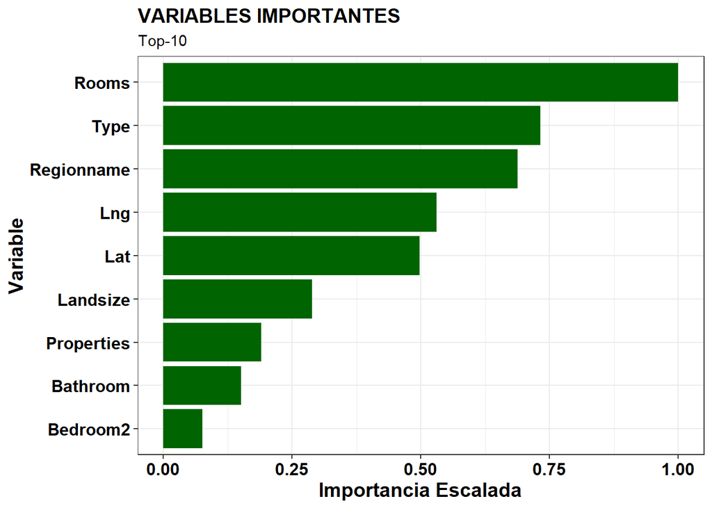

```r
# Variables Importantes - Modelo Ganador
var_import <- h2o.varimp(aml@leader)

ggplot(var_import[1:9, ], aes( x = fct_reorder(variable, scaled_importance), y = scaled_importance)) +
  geom_col(fill = 'darkgreen') +
  coord_flip() +
  labs(
        title    = "VARIABLES IMPORTANTES" ,
        subtitle = "Top-10",
        y        = 'Importancia Escalada',
        x        = "Variable"
      ) +
  theme_bw() +
  theme(
    # Labels appearance
    plot.title   = element_text(size = 14, face = "bold", colour = "black" ),
    axis.title.x = element_text(size = 14, face = "bold", colour = "black"),
    axis.title.y = element_text(size = 14, face = "bold", colour = "black"),
    axis.text.x  = element_text(size = 12, face = "bold", colour = "black"),
    axis.text.y  = element_text(size = 12, face = "bold", colour = "black")
  )
```

```r
aml_perf     <- h2o.performance(model = aml@leader, newdata = test)
err_val_pre  <- h2o.rmse(aml_perf)
print(err_val_pre)
```

```
## [1] 0.2059511
```

### Feature Engineering

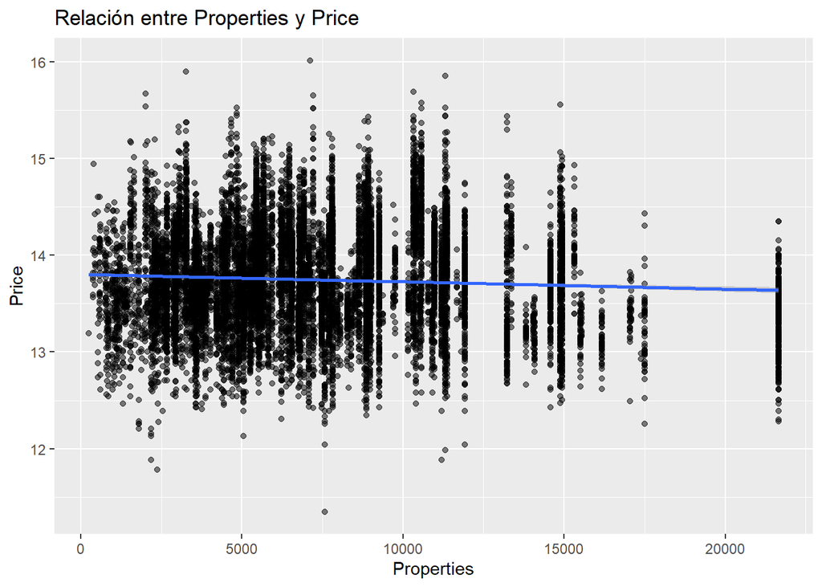

```r
# Se profundiza la relación entre Properties y Price
ggplot(data          = datMelbourneMod, aes(x = Properties, y = Price)) +
  geom_point(alpha   = 0.5) +
  geom_smooth(method = "lm") +
  labs(title         = "Relación entre Properties y Price", x = "Properties", y = "Price")
```

La línea azul que muestra la tendenci es casi horizontal. Esto sugiere que no hay una relación fuerte o clara entre Properties y Price: es decir, el número de viviendas en la zona no parece tener un efecto significativo en los precios de las propiedades en este dataset. Por otro lado, se observa una alta variabilidad en los precios, lo cual nos indica que otros factores podrían estar influyendo más significativamente en los precios de las propiedades.

```r
# Crear una nueva columna 'Properties_cluster' basada en los rangos definidos
datMelbourneMod2 <- datMelbourneMod %>%
  mutate(Properties_cluster = case_when(
    Properties <= 2500 ~ "h2500",
    Properties <= 5000 ~ "2500to5000",
    Properties <= 7500 ~ "5000to7500",
    Properties <= 10000 ~ "7500to10000",
    TRUE ~ "m10000"
  )) %>%
  as.data.table()

# Verificar los resultados
table(datMelbourneMod2$Properties_cluster)
```

```
##
##  2500to5000  5000to7500 7500to10000       h2500      m10000
##        3157        3685        2107        1127        3481
```

```r
# se agrupan las variable de habitaciones
datroom <- datMelbourneMod2 %>%
  select(Rooms, Bathroom, Bedroom2) %>%
  as.data.table()
```

```r
datMelbourneMod2 <- datMelbourneMod2 %>%
  # se crea una nueva variable para todas las habitaciones
  mutate( fe_tothabi         = rowSums(datroom)) %>%
  # se crea una variable para la distancia
  mutate( fe_dist            = sqrt(Lng^2 + Lat^2)) %>%
  # se modifica a factor la variable Properties
  mutate( Properties_cluster = factor(Properties_cluster)) %>%
  select(-c(Rooms, Properties))  %>%
  as.data.table()
```

```r
# se imputan los valores faltantes
datMelbourneMod3 <- missRanger(datMelbourneMod2, verbose = 0)
```

Aunque no es una transformación obligatoria, se decide pasar las variables categoricas a la codificación one-hot para capturar relaciones más complejas, y así mejorar el rendimiento de algunos modelos (Redes neuronales, árboles de decisión, k-NN, SVM). Se tiene en cuenta que, dado el reducido número de variables categoricas y sus niveles, esto no repercute tan negativamente sobre la dimensionalidad del conjunto de variables.

```r
# se crean funciones para transformar los factores en dummies
columna_dummy <- function(df, columna) {
  df %>%
  mutate_at(columna, ~paste(columna, eval(as.symbol(columna)), sep = "_")) %>%
    mutate(valor = 1) %>%
    spread(key = columna, value = valor, fill = 0)
}

crear_dummies <- function(df, nombres) {
  map(c("Regionname", "Type", "Properties_cluster"), columna_dummy, df = datMelbourneMod3) %>%
    reduce(inner_join) %>%
    select(-all_of(nombres))
}
```

```r
# se aplican las funciones
datMelbourneMod3 <- crear_dummies(datMelbourneMod3, c("Regionname", "Type","Properties_cluster"))
```

[output not shown]

```r
skim(datMelbourneMod3)
```

Data summary

| Name | datMelbourneMod3 |
| --- | --- |
| Number of rows | 13557 |
| Number of columns | 24 |
| _______________________ |  |
| Column type frequency: |  |
| numeric | 24 |
| ________________________ |  |
| Group variables | None |

**Variable type: numeric**

| skim_variable | n_missing | complete_rate | mean | sd | p0 | p25 | p50 | p75 | p100 | hist |
| --- | --- | --- | --- | --- | --- | --- | --- | --- | --- | --- |
| Bedroom2 | 0 | 1 | 2.92 | 0.97 | 0.00 | 2.00 | 3.00 | 3.00 | 20.00 | ▇▁▁▁▁ |
| Bathroom | 0 | 1 | 1.53 | 0.69 | 0.00 | 1.00 | 1.00 | 2.00 | 8.00 | ▇▆▁▁▁ |
| Landsize | 0 | 1 | 783.53 | 4047.60 | 1.00 | 296.00 | 564.00 | 731.00 | 433014.00 | ▇▁▁▁▁ |
| Lat | 0 | 1 | -37.81 | 0.08 | -38.18 | -37.86 | -37.80 | -37.76 | -37.41 | ▁▂▇▁▁ |
| Lng | 0 | 1 | 145.00 | 0.10 | 144.43 | 144.93 | 145.00 | 145.06 | 145.53 | ▁▁▇▂▁ |
| Price | 0 | 1 | 13.75 | 0.53 | 11.35 | 13.38 | 13.71 | 14.10 | 16.01 | ▁▂▇▃▁ |
| fe_tothabi | 0 | 1 | 7.39 | 2.37 | 2.00 | 5.00 | 7.00 | 9.00 | 24.00 | ▅▇▁▁▁ |
| fe_dist | 0 | 1 | 149.84 | 0.11 | 149.26 | 149.77 | 149.85 | 149.91 | 150.39 | ▁▁▇▂▁ |
| Regionname_EasternMetropolitan | 0 | 1 | 0.11 | 0.31 | 0.00 | 0.00 | 0.00 | 0.00 | 1.00 | ▇▁▁▁▁ |
| Regionname_EasternVictoria | 0 | 1 | 0.00 | 0.06 | 0.00 | 0.00 | 0.00 | 0.00 | 1.00 | ▇▁▁▁▁ |
| Regionname_NorthernMetropolitan | 0 | 1 | 0.29 | 0.45 | 0.00 | 0.00 | 0.00 | 1.00 | 1.00 | ▇▁▁▁▃ |
| Regionname_NorthernVictoria | 0 | 1 | 0.00 | 0.05 | 0.00 | 0.00 | 0.00 | 0.00 | 1.00 | ▇▁▁▁▁ |
| Regionname_SouthEasternMetropolitan | 0 | 1 | 0.03 | 0.18 | 0.00 | 0.00 | 0.00 | 0.00 | 1.00 | ▇▁▁▁▁ |
| Regionname_SouthernMetropolitan | 0 | 1 | 0.35 | 0.48 | 0.00 | 0.00 | 0.00 | 1.00 | 1.00 | ▇▁▁▁▅ |
| Regionname_WesternMetropolitan | 0 | 1 | 0.22 | 0.41 | 0.00 | 0.00 | 0.00 | 0.00 | 1.00 | ▇▁▁▁▂ |
| Regionname_WesternVictoria | 0 | 1 | 0.00 | 0.05 | 0.00 | 0.00 | 0.00 | 0.00 | 1.00 | ▇▁▁▁▁ |
| Type_h | 0 | 1 | 0.70 | 0.46 | 0.00 | 0.00 | 1.00 | 1.00 | 1.00 | ▃▁▁▁▇ |
| Type_t | 0 | 1 | 0.08 | 0.27 | 0.00 | 0.00 | 0.00 | 0.00 | 1.00 | ▇▁▁▁▁ |
| Type_u | 0 | 1 | 0.22 | 0.42 | 0.00 | 0.00 | 0.00 | 0.00 | 1.00 | ▇▁▁▁▂ |
| Properties_cluster_2500to5000 | 0 | 1 | 0.23 | 0.42 | 0.00 | 0.00 | 0.00 | 0.00 | 1.00 | ▇▁▁▁▂ |
| Properties_cluster_5000to7500 | 0 | 1 | 0.27 | 0.44 | 0.00 | 0.00 | 0.00 | 1.00 | 1.00 | ▇▁▁▁▃ |
| Properties_cluster_7500to10000 | 0 | 1 | 0.16 | 0.36 | 0.00 | 0.00 | 0.00 | 0.00 | 1.00 | ▇▁▁▁▂ |
| Properties_cluster_h2500 | 0 | 1 | 0.08 | 0.28 | 0.00 | 0.00 | 0.00 | 0.00 | 1.00 | ▇▁▁▁▁ |
| Properties_cluster_m10000 | 0 | 1 | 0.26 | 0.44 | 0.00 | 0.00 | 0.00 | 1.00 | 1.00 | ▇▁▁▁▃ |

### Nuevo modelo H2o

```r
h2o.no_progress()

data   <- as.h2o(datMelbourneMod3)

train  <- h2o.splitFrame(data, ratios = c(0.7,0.15), seed =1)[[1]]
valid  <- h2o.splitFrame(data, ratios = c(0.7,0.15), seed =1)[[2]]
test   <- h2o.splitFrame(data, ratios = c(0.7,0.15), seed =1)[[3]]

y      <- "Price"
x      <- setdiff(names(data), y)

print(x)
```

```
##  [1] "Bedroom2"                            "Bathroom"
##  [3] "Landsize"                            "Lat"
##  [5] "Lng"                                 "fe_tothabi"
##  [7] "fe_dist"                             "Regionname_EasternMetropolitan"
##  [9] "Regionname_EasternVictoria"          "Regionname_NorthernMetropolitan"
## [11] "Regionname_NorthernVictoria"         "Regionname_SouthEasternMetropolitan"
## [13] "Regionname_SouthernMetropolitan"     "Regionname_WesternMetropolitan"
## [15] "Regionname_WesternVictoria"          "Type_h"
## [17] "Type_t"                              "Type_u"
## [19] "Properties_cluster_2500to5000"       "Properties_cluster_5000to7500"
## [21] "Properties_cluster_7500to10000"      "Properties_cluster_h2500"
## [23] "Properties_cluster_m10000"
```

```r
aml <- h2o.automl(
                    x                  = x,
                    y                  = y,
                    training_frame     = train,
                    validation_frame   = valid,
                    nfold              = 3,
                    max_runtime_secs   = 300,
                    stopping_metric    = "RMSE",
                    exclude_algos      = c("GLM", "StackedEnsemble"),
                    stopping_tolerance = 0.1,
                    stopping_rounds    = 5,
                    seed               = 12345,
                    sort_metric        = c("RMSE")
                 )
```

```
##
## 16:58:04.79: User specified a validation frame with cross-validation still enabled. Please note that the models will still be validated using cross-validation only, the validation frame will be used to provide purely informative validation metrics on the trained models.
## 16:58:04.86: AutoML: XGBoost is not available; skipping it.
```

```r
lb <- aml@leaderboard

#-- Tabla de modelos top-10 y worst-10.
lb_df <- as.data.frame(lb)
lb_df %>% head(10) %>% kbl(caption = "Top-10 Mejores Modelo Ejecutados - Ordenados por RMSE") %>% kable_minimal()
```

Top-10 Mejores Modelo Ejecutados - Ordenados por RMSE

| model_id | rmse | mse | mae | rmsle | mean_residual_deviance |
| --- | --- | --- | --- | --- | --- |
| GBM_4_AutoML_2_20240814_165804 | 0.2015607 | 0.0406267 | 0.1483298 | 0.0136357 | 0.0406267 |
| GBM_3_AutoML_2_20240814_165804 | 0.2037415 | 0.0415106 | 0.1499323 | 0.0137742 | 0.0415106 |
| GBM_grid_1_AutoML_2_20240814_165804_model_21 | 0.2042930 | 0.0417356 | 0.1499117 | 0.0138186 | 0.0417356 |
| GBM_grid_1_AutoML_2_20240814_165804_model_7 | 0.2043285 | 0.0417501 | 0.1497305 | 0.0138246 | 0.0417501 |
| GBM_grid_1_AutoML_2_20240814_165804_model_10 | 0.2046875 | 0.0418970 | 0.1508444 | 0.0138464 | 0.0418970 |
| GBM_grid_1_AutoML_2_20240814_165804_model_1 | 0.2054215 | 0.0421980 | 0.1512552 | 0.0138973 | 0.0421980 |
| GBM_grid_1_AutoML_2_20240814_165804_model_17 | 0.2055522 | 0.0422517 | 0.1519295 | 0.0139124 | 0.0422517 |
| GBM_2_AutoML_2_20240814_165804 | 0.2060264 | 0.0424469 | 0.1519616 | 0.0139256 | 0.0424469 |
| GBM_grid_1_AutoML_2_20240814_165804_model_16 | 0.2084598 | 0.0434555 | 0.1545396 | 0.0140836 | 0.0434555 |
| GBM_5_AutoML_2_20240814_165804 | 0.2085352 | 0.0434869 | 0.1535887 | 0.0140877 | 0.0434869 |

```r
lb_df %>% tail(10) %>% kbl(caption = "Top-10 Peores Modelo Ejecutados - Ordenados por RMSE") %>% kable_minimal()
```

Top-10 Peores Modelo Ejecutados - Ordenados por RMSE

|  | model_id | rmse | mse | mae | rmsle | mean_residual_deviance |
| --- | --- | --- | --- | --- | --- | --- |
| 26 | GBM_grid_1_AutoML_2_20240814_165804_model_6 | 0.2302238 | 0.0530030 | 0.1732392 | 0.0155463 | 0.0530030 |
| 27 | GBM_grid_1_AutoML_2_20240814_165804_model_3 | 0.2318442 | 0.0537517 | 0.1741621 | 0.0156509 | 0.0537517 |
| 28 | GBM_grid_1_AutoML_2_20240814_165804_model_4 | 0.2393049 | 0.0572668 | 0.1808080 | 0.0161476 | 0.0572668 |
| 29 | DeepLearning_1_AutoML_2_20240814_165804 | 0.2627815 | 0.0690541 | 0.1993772 | 0.0177682 | 0.0690541 |
| 30 | DeepLearning_grid_1_AutoML_2_20240814_165804_model_1 | 0.2656625 | 0.0705766 | 0.1863909 | 0.0177489 | 0.0705766 |
| 31 | DeepLearning_grid_1_AutoML_2_20240814_165804_model_2 | 0.2695595 | 0.0726623 | 0.1878616 | 0.0182362 | 0.0726623 |
| 32 | DeepLearning_grid_1_AutoML_2_20240814_165804_model_3 | 0.2798761 | 0.0783307 | 0.2008996 | 0.0187511 | 0.0783307 |
| 33 | DeepLearning_grid_1_AutoML_2_20240814_165804_model_5 | 0.3006997 | 0.0904203 | 0.2339905 | 0.0203318 | 0.0904203 |
| 34 | DeepLearning_grid_1_AutoML_2_20240814_165804_model_6 | 0.3033027 | 0.0919925 | 0.2339063 | 0.0204777 | 0.0919925 |
| 35 | DeepLearning_grid_1_AutoML_2_20240814_165804_model_4 | 0.3583887 | 0.1284425 | 0.2338434 | 0.0268280 | 0.1284425 |

```r
# Modelo ganador.
win_mod <- word(lb_df$model_id[1], 1, sep = fixed("_"))

# Modelo Ganador
best_mod <- aml@leader
best_mod
```

```
## Model Details:
## ==============
##
## H2ORegressionModel: gbm
## Model ID:  GBM_4_AutoML_2_20240814_165804
## Model Summary:
##   number_of_trees number_of_internal_trees model_size_in_bytes min_depth
## 1              60                       60              157347        10
##   max_depth mean_depth min_leaves max_leaves mean_leaves
## 1        10   10.00000         55        337   204.06667
##
##
## H2ORegressionMetrics: gbm
## ** Reported on training data. **
##
## MSE:  0.02102511
## RMSE:  0.1450004
## MAE:  0.1071146
## RMSLE:  0.009791735
## Mean Residual Deviance :  0.02102511
##
##
## H2ORegressionMetrics: gbm
## ** Reported on validation data. **
## ** Validation metrics **
##
## MSE:  0.0381944
## RMSE:  0.1954339
## MAE:  0.1442799
## RMSLE:  0.01328947
## Mean Residual Deviance :  0.0381944
##
##
## H2ORegressionMetrics: gbm
## ** Reported on cross-validation data. **
## ** 3-fold cross-validation on training data (Metrics computed for combined holdout predictions) **
##
## MSE:  0.04062671
## RMSE:  0.2015607
## MAE:  0.1483298
## RMSLE:  0.01363566
## Mean Residual Deviance :  0.04062671
##
##
## Cross-Validation Metrics Summary:
##                            mean       sd cv_1_valid cv_2_valid cv_3_valid
## mae                    0.148330 0.001950   0.150558   0.146938   0.147493
## mean_residual_deviance 0.040627 0.001688   0.041736   0.041460   0.038685
## mse                    0.040627 0.001688   0.041736   0.041460   0.038685
## r2                     0.853595 0.004009   0.856980   0.849167   0.854638
## residual_deviance      0.040627 0.001688   0.041736   0.041460   0.038685
## rmse                   0.201531 0.004212   0.204293   0.203617   0.196684
## rmsle                  0.013634 0.000288   0.013777   0.013822   0.013302
```

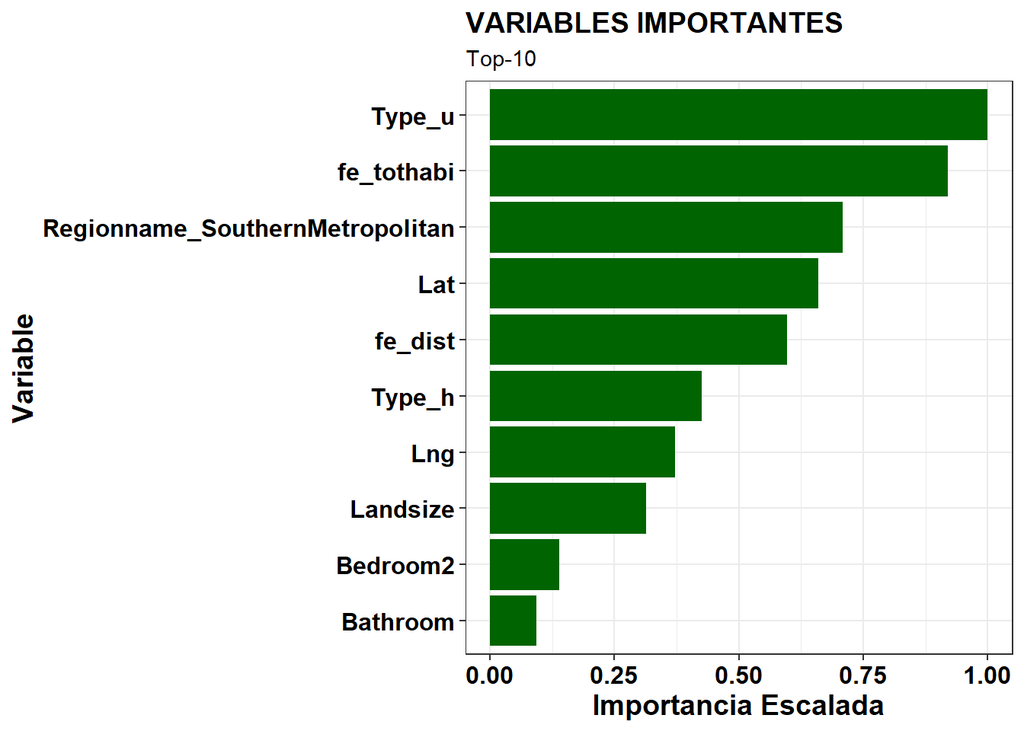

```r
# Variables Importantes - Modelo Ganador
var_import <- h2o.varimp(aml@leader)


ggplot(var_import[1:10, ], aes( x = fct_reorder(variable, scaled_importance), y = scaled_importance)) +
  geom_col(fill = 'darkgreen') +
  coord_flip() +
  labs(
        title    = "VARIABLES IMPORTANTES" ,
        subtitle = "Top-10",
        y        = 'Importancia Escalada',
        x        = "Variable"
      ) +
  theme_bw() +
  theme(
    # Labels appearance
    plot.title   = element_text(size = 14, face = "bold", colour = "black" ),
    axis.title.x = element_text(size = 14, face = "bold", colour = "black"),
    axis.title.y = element_text(size = 14, face = "bold", colour = "black"),
    axis.text.x  = element_text(size = 12, face = "bold", colour = "black"),
    axis.text.y  = element_text(size = 12, face = "bold", colour = "black")
  )
```

```r
#--- Error
aml_perf <- h2o.performance(model = aml@leader, newdata = test)
err_val_post  <- h2o.rmse(aml_perf)
print(err_val_post)
```

```
## [1] 0.2077889
```

```r
error_df <- data.frame(
  Pre         = err_val_pre,
  Post        = err_val_post
)

error_df %>%
  kbl(caption = "Diferencias de error pre-post") %>%
  kable_minimal()
```

Diferencias de error pre-post

| Pre | Post |
| --- | --- |
| 0.2059511 | 0.2077889 |